# R Notebook

# Zahra Soukhtedel 98105138

```r
library(data.table)
library(ggplot2)
```

```r
d1 = fread('C:/Users/acer/Desktop/New folder/diabetes_012_health_indicators_BRFSS2015.csv', encoding = 'UTF-8')
d2 = fread('C:/Users/acer/Desktop/New folder/diabetes_binary_5050split_health_indicators_BRFSS2015.csv', encoding = 'UTF-8')
d3 = fread('C:/Users/acer/Desktop/New folder/diabetes_binary_health_indicators_BRFSS2015.csv', encoding = 'UTF-8')
```

### Q1: we do some EDA on our data to indicate that our features are good enough to have a model for predicting or not.

```r
head(d1)
```

| Diabetes_012 | HighBP | HighChol | CholCheck | BMI | Smoker | Stroke | HeartDiseaseorAttack | PhysActivity | Fruits | Veggies | HvyAlcoholConsump | AnyHealthcare | NoDocbcCost | GenHlth | MentHlth | PhysHlth | DiffWalk | Sex | Age | Education | Income |
| --- | --- | --- | --- | --- | --- | --- | --- | --- | --- | --- | --- | --- | --- | --- | --- | --- | --- | --- | --- | --- | --- |
| 0 | 1 | 1 | 1 | 40 | 1 | 0 | 0 | 0 | 0 | 1 | 0 | 1 | 0 | 5 | 18 | 15 | 1 | 0 | 9 | 4 | 3 |
| 0 | 0 | 0 | 0 | 25 | 1 | 0 | 0 | 1 | 0 | 0 | 0 | 0 | 1 | 3 | 0 | 0 | 0 | 0 | 7 | 6 | 1 |
| 0 | 1 | 1 | 1 | 28 | 0 | 0 | 0 | 0 | 1 | 0 | 0 | 1 | 1 | 5 | 30 | 30 | 1 | 0 | 9 | 4 | 8 |
| 0 | 1 | 0 | 1 | 27 | 0 | 0 | 0 | 1 | 1 | 1 | 0 | 1 | 0 | 2 | 0 | 0 | 0 | 0 | 11 | 3 | 6 |
| 0 | 1 | 1 | 1 | 24 | 0 | 0 | 0 | 1 | 1 | 1 | 0 | 1 | 0 | 2 | 3 | 0 | 0 | 0 | 11 | 5 | 4 |
| 0 | 1 | 1 | 1 | 25 | 1 | 0 | 0 | 1 | 1 | 1 | 0 | 1 | 0 | 2 | 0 | 2 | 0 | 1 | 10 | 6 | 8 |

```r
str(d1)
```

```
Classes ‘data.table’ and 'data.frame':  253680 obs. of  22 variables:
 $ Diabetes_012        : num  0 0 0 0 0 0 0 0 2 0 ...
 $ HighBP              : num  1 0 1 1 1 1 1 1 1 0 ...
 $ HighChol            : num  1 0 1 0 1 1 0 1 1 0 ...
 $ CholCheck           : num  1 0 1 1 1 1 1 1 1 1 ...
 $ BMI                 : num  40 25 28 27 24 25 30 25 30 24 ...
 $ Smoker              : num  1 1 0 0 0 1 1 1 1 0 ...
 $ Stroke              : num  0 0 0 0 0 0 0 0 0 0 ...
 $ HeartDiseaseorAttack: num  0 0 0 0 0 0 0 0 1 0 ...
 $ PhysActivity        : num  0 1 0 1 1 1 0 1 0 0 ...
 $ Fruits              : num  0 0 1 1 1 1 0 0 1 0 ...
 $ Veggies             : num  1 0 0 1 1 1 0 1 1 1 ...
 $ HvyAlcoholConsump   : num  0 0 0 0 0 0 0 0 0 0 ...
 $ AnyHealthcare       : num  1 0 1 1 1 1 1 1 1 1 ...
 $ NoDocbcCost         : num  0 1 1 0 0 0 0 0 0 0 ...
 $ GenHlth             : num  5 3 5 2 2 2 3 3 5 2 ...
 $ MentHlth            : num  18 0 30 0 3 0 0 0 30 0 ...
 $ PhysHlth            : num  15 0 30 0 0 2 14 0 30 0 ...
 $ DiffWalk            : num  1 0 1 0 0 0 0 1 1 0 ...
 $ Sex                 : num  0 0 0 0 0 1 0 0 0 1 ...
 $ Age                 : num  9 7 9 11 11 10 9 11 9 8 ...
 $ Education           : num  4 6 4 3 5 6 6 4 5 4 ...
 $ Income              : num  3 1 8 6 4 8 7 4 1 3 ...
 - attr(*, ".internal.selfref")=<externalptr>
```

```r
summary(d1)
```

```
  Diabetes_012        HighBP         HighChol        CholCheck           BMI
 Min.   :0.0000   Min.   :0.000   Min.   :0.0000   Min.   :0.0000   Min.   :12.00
 1st Qu.:0.0000   1st Qu.:0.000   1st Qu.:0.0000   1st Qu.:1.0000   1st Qu.:24.00
 Median :0.0000   Median :0.000   Median :0.0000   Median :1.0000   Median :27.00
 Mean   :0.2969   Mean   :0.429   Mean   :0.4241   Mean   :0.9627   Mean   :28.38
 3rd Qu.:0.0000   3rd Qu.:1.000   3rd Qu.:1.0000   3rd Qu.:1.0000   3rd Qu.:31.00
 Max.   :2.0000   Max.   :1.000   Max.   :1.0000   Max.   :1.0000   Max.   :98.00
     Smoker           Stroke        HeartDiseaseorAttack  PhysActivity        Fruits
 Min.   :0.0000   Min.   :0.00000   Min.   :0.00000      Min.   :0.0000   Min.   :0.0000
 1st Qu.:0.0000   1st Qu.:0.00000   1st Qu.:0.00000      1st Qu.:1.0000   1st Qu.:0.0000
 Median :0.0000   Median :0.00000   Median :0.00000      Median :1.0000   Median :1.0000
 Mean   :0.4432   Mean   :0.04057   Mean   :0.09419      Mean   :0.7565   Mean   :0.6343
 3rd Qu.:1.0000   3rd Qu.:0.00000   3rd Qu.:0.00000      3rd Qu.:1.0000   3rd Qu.:1.0000
 Max.   :1.0000   Max.   :1.00000   Max.   :1.00000      Max.   :1.0000   Max.   :1.0000
    Veggies       HvyAlcoholConsump AnyHealthcare     NoDocbcCost         GenHlth
 Min.   :0.0000   Min.   :0.0000    Min.   :0.0000   Min.   :0.00000   Min.   :1.000
 1st Qu.:1.0000   1st Qu.:0.0000    1st Qu.:1.0000   1st Qu.:0.00000   1st Qu.:2.000
 Median :1.0000   Median :0.0000    Median :1.0000   Median :0.00000   Median :2.000
 Mean   :0.8114   Mean   :0.0562    Mean   :0.9511   Mean   :0.08418   Mean   :2.511
 3rd Qu.:1.0000   3rd Qu.:0.0000    3rd Qu.:1.0000   3rd Qu.:0.00000   3rd Qu.:3.000
 Max.   :1.0000   Max.   :1.0000    Max.   :1.0000   Max.   :1.00000   Max.   :5.000
    MentHlth         PhysHlth         DiffWalk           Sex              Age
 Min.   : 0.000   Min.   : 0.000   Min.   :0.0000   Min.   :0.0000   Min.   : 1.000
 1st Qu.: 0.000   1st Qu.: 0.000   1st Qu.:0.0000   1st Qu.:0.0000   1st Qu.: 6.000
 Median : 0.000   Median : 0.000   Median :0.0000   Median :0.0000   Median : 8.000
 Mean   : 3.185   Mean   : 4.242   Mean   :0.1682   Mean   :0.4403   Mean   : 8.032
 3rd Qu.: 2.000   3rd Qu.: 3.000   3rd Qu.:0.0000   3rd Qu.:1.0000   3rd Qu.:10.000
 Max.   :30.000   Max.   :30.000   Max.   :1.0000   Max.   :1.0000   Max.   :13.000
   Education        Income
 Min.   :1.00   Min.   :1.000
 1st Qu.:4.00   1st Qu.:5.000
 Median :5.00   Median :7.000
 Mean   :5.05   Mean   :6.054
 3rd Qu.:6.00   3rd Qu.:8.000
 Max.   :6.00   Max.   :8.000
```

```r
names(d1)
```

```
 [1] "Diabetes_012"         "HighBP"               "HighChol"
 [4] "CholCheck"            "BMI"                  "Smoker"
 [7] "Stroke"               "HeartDiseaseorAttack" "PhysActivity"
[10] "Fruits"               "Veggies"              "HvyAlcoholConsump"
[13] "AnyHealthcare"        "NoDocbcCost"          "GenHlth"
[16] "MentHlth"             "PhysHlth"             "DiffWalk"
[19] "Sex"                  "Age"                  "Education"
[22] "Income"
```

```r
names(d2)
```

```
 [1] "Diabetes_binary"      "HighBP"               "HighChol"
 [4] "CholCheck"            "BMI"                  "Smoker"
 [7] "Stroke"               "HeartDiseaseorAttack" "PhysActivity"
[10] "Fruits"               "Veggies"              "HvyAlcoholConsump"
[13] "AnyHealthcare"        "NoDocbcCost"          "GenHlth"
[16] "MentHlth"             "PhysHlth"             "DiffWalk"
[19] "Sex"                  "Age"                  "Education"
[22] "Income"
```

```r
names(d3)
```

```
 [1] "Diabetes_binary"      "HighBP"               "HighChol"
 [4] "CholCheck"            "BMI"                  "Smoker"
 [7] "Stroke"               "HeartDiseaseorAttack" "PhysActivity"
[10] "Fruits"               "Veggies"              "HvyAlcoholConsump"
[13] "AnyHealthcare"        "NoDocbcCost"          "GenHlth"
[16] "MentHlth"             "PhysHlth"             "DiffWalk"
[19] "Sex"                  "Age"                  "Education"
[22] "Income"
```

Second investigating the contributition of the predictors as risk factors for diabetes prediction.

#### Age:

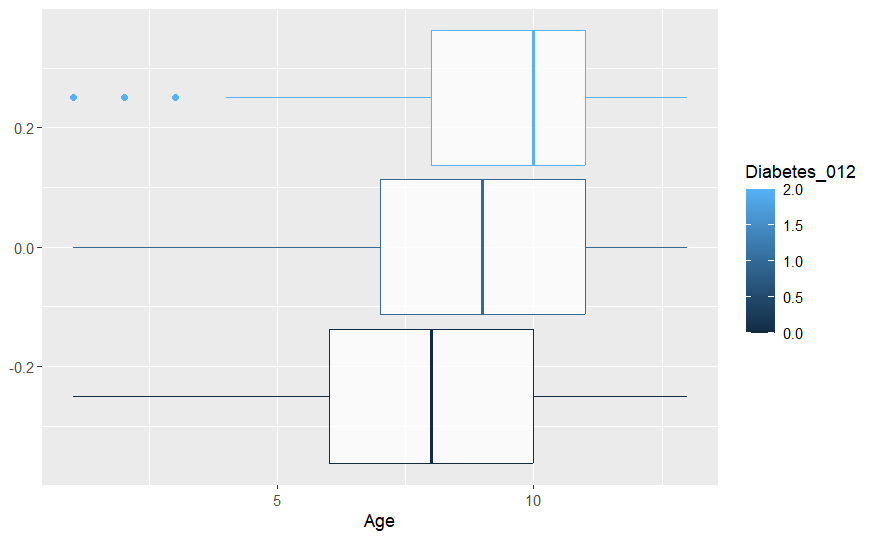

```r
ggplot(d1, aes(Age, group = Diabetes_012, color = Diabetes_012)) + geom_boxplot(alpha = 0.75)
```

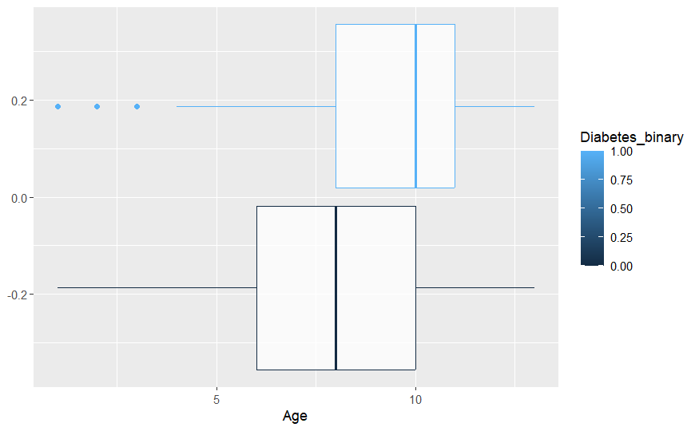

```r
ggplot(d2, aes(Age, group = Diabetes_binary, color = Diabetes_binary)) + geom_boxplot(alpha = 0.75)
```

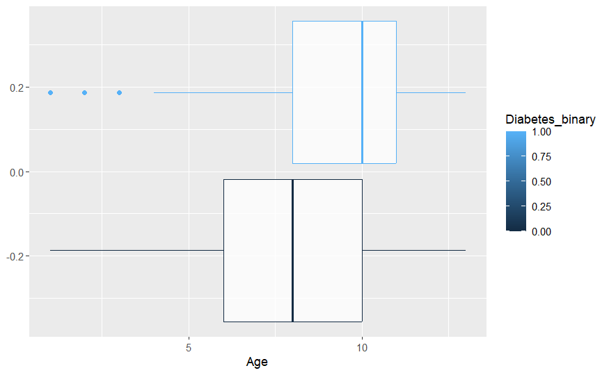

```r
ggplot(d3, aes(Age, group = Diabetes_binary, color = Diabetes_binary)) + geom_boxplot(alpha = 0.75)
```

#### BMI

```r
d1$Diabetes_012 = as.factor(d1$Diabetes_012)
d2$Diabetes_binary = as.factor(d2$Diabetes_binary)
d3$Diabetes_binary = as.factor(d3$Diabetes_binary)
```

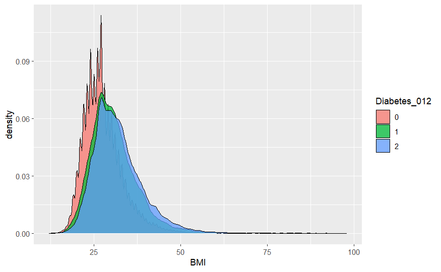

```r
ggplot(d1, aes(BMI, fill=Diabetes_012)) + geom_density(alpha=0.75)
```

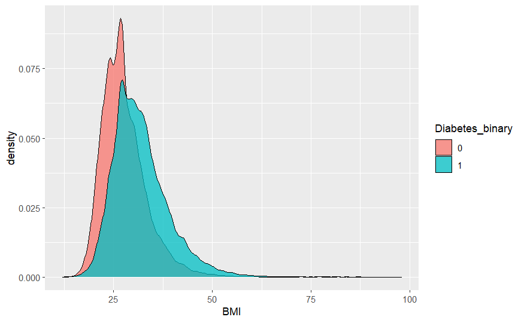

```r
ggplot(d2, aes(BMI, fill=Diabetes_binary)) + geom_density(alpha=0.75)
```

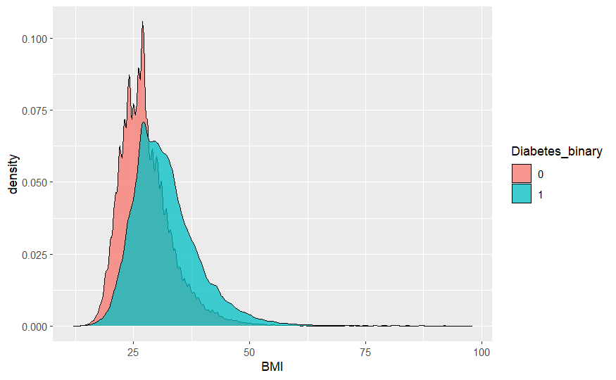

```r
ggplot(d3, aes(BMI, fill=Diabetes_binary)) + geom_density(alpha=0.75)
```

From the plots above, It appears that people with lower BMI scores are less susceptible to Diabetes, and those with prediabetes or diabetes have very similar BMI scores. Their histograms can also be compared for further analysis.

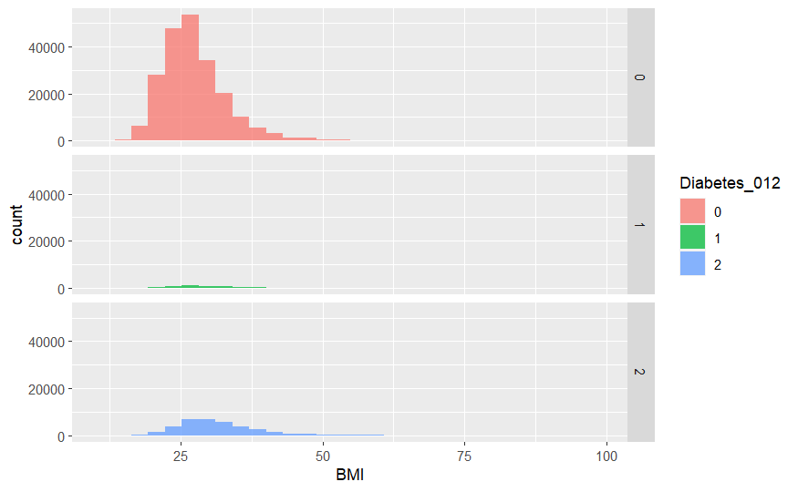

```r
ggplot(d1, aes(BMI, fill=Diabetes_012)) + geom_histogram(alpha=0.75) + facet_grid(Diabetes_012 ~ .)
```

We understand that a histogram displays the frequency of values within each range, whereas a density plot illustrates the proportion of values within each range. Given that the data is unbalanced, we can accurately compare them using either a density plot or a histogram with ‘free_y’.

In general, the most common BMI distribution falls between 22 and 30, and it is a significant risk factor for the development of diabetes. A higher BMI is associated with an increased likelihood of developing the disease.

#### Education

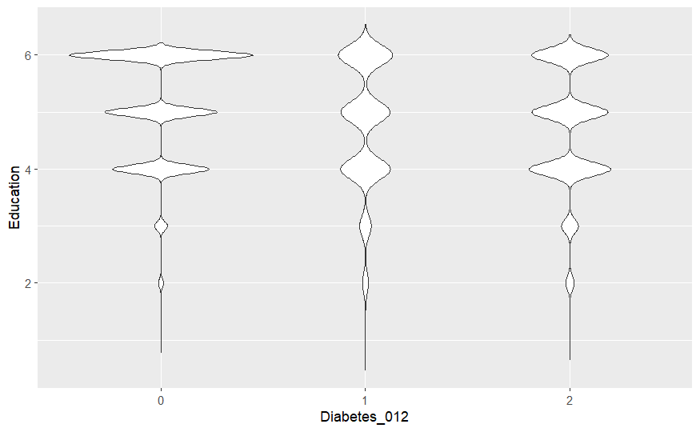

```r
ggplot(d1, aes(x=Diabetes_012, y=Education)) + geom_violin(trim=FALSE)
```

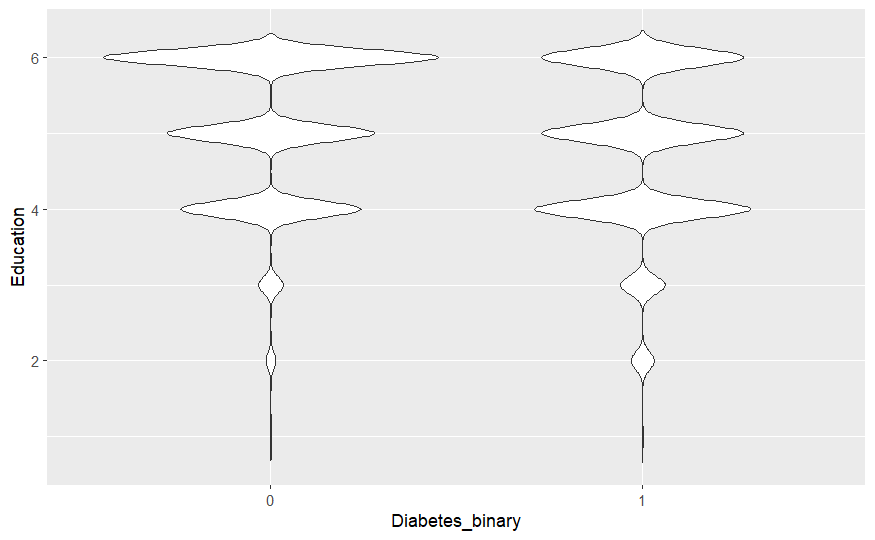

```r
ggplot(d2, aes(x=Diabetes_binary, y=Education)) + geom_violin(trim=FALSE)
```

#### NoDocbcCost

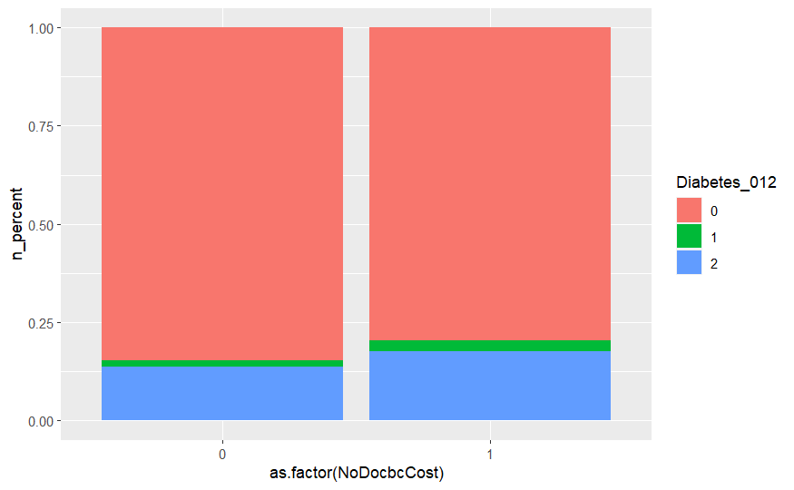

```r
d1$one = 1
ds = d1[, .(n = sum(one)), .(Diabetes_012, NoDocbcCost)]
ds[, n_total := sum(n), .(NoDocbcCost)]
ds[, n_percent := n/n_total]
ggplot(ds, aes(as.factor(NoDocbcCost), n_percent, fill = Diabetes_012)) + geom_bar(stat = 'identity',)
```

There appears to be a correlation between prediabetes and diabetes with the factor of financial constraints in accessing healthcare. The question “Was there a time in the past 12 months when you needed to see a doctor but could not because of cost? 0 = no, 1 = yes” aligns with this relationship, which is logical.

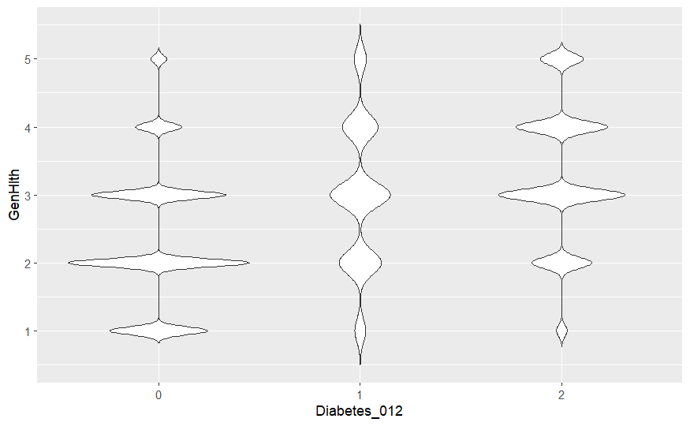

```r
ggplot(d1, aes(x=Diabetes_012, y=GenHlth)) +
  geom_violin(trim=FALSE)
```

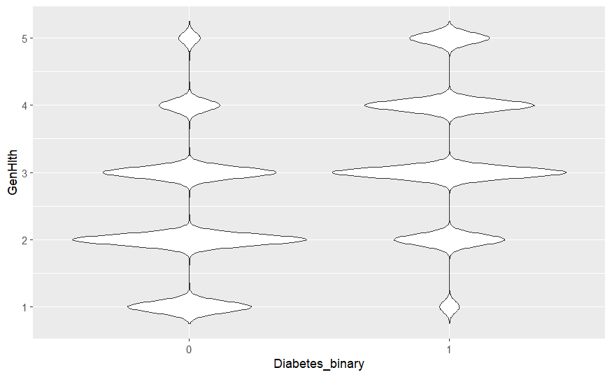

```r
ggplot(d2, aes(x=Diabetes_binary, y=GenHlth)) +
  geom_violin(trim=FALSE)
```

#### Income

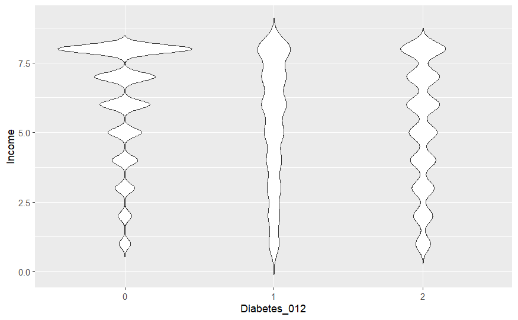

```r
ggplot(d1, aes(x=Diabetes_012, y=Income)) + geom_violin(trim=FALSE)
```

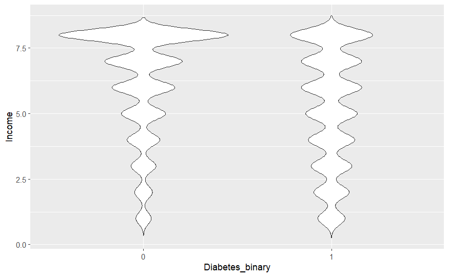

```r
ggplot(d2, aes(x=Diabetes_binary, Income)) + geom_violin(trim=FALSE)
```

### Q2: Feature Selection

#### Random Foresrt

Random forest does feature selection, that best explains the variance in the response variable.

```r
# install.packages("party")
library(party)
Diabetes_binary <- as.factor(d2$Diabetes_binary)
cf1 <- cforest(as.factor(Diabetes_binary) ~ . , data= d2, control=cforest_unbiased(mtry=3,ntree=100))
```

#### Step-wise Regression

If you have a substantial number of predictors (more than 15), divide the inputData into chunks of 10 predictors. Each chunk should include the responseVar variable.

```r
d2 = fread('C:/Users/acer/Desktop/New folder/diabetes_binary_5050split_health_indicators_BRFSS2015.csv', encoding = 'UTF-8')
Diabetes_binary <- as.factor(d2$Diabetes_binary)
base.mod <- lm(Diabetes_binary ~ 1 , data= d2)
all.mod <- lm(Diabetes_binary ~ . , data= d2)
stepMod <- step(base.mod, scope = list(lower = base.mod, upper = all.mod), direction = "both", trace = 0, steps = 1000)
shortlistedVars <- names(unlist(stepMod[[1]]))
shortlistedVars <- shortlistedVars[!shortlistedVars %in% "(Intercept)"]
print(shortlistedVars)
```

```
 [1] "GenHlth"              "HighBP"               "BMI"
 [4] "Age"                  "HighChol"             "HvyAlcoholConsump"
 [7] "CholCheck"            "Income"               "Sex"
[10] "HeartDiseaseorAttack" "PhysHlth"             "DiffWalk"
[13] "Education"            "MentHlth"             "Stroke"
[16] "Veggies"              "PhysActivity"         "AnyHealthcare"
[19] "Fruits"
```

The output may contain levels within categorical variables because the ‘stepwise’ technique is based on linear regression, as demonstrated earlier. As anticipated, features such as GenHlth, HighBp, BMI, Age, HighChol, etc., hold greater significance. It’s important to note that due to the step-wise feature selection approach, we do not expect the absolute best model, but rather a model and result that closely approximate the optimal one.

#### MARS

The earth package incorporates variable importance using Generalized Cross Validation (GCV), the number of subset models in which the variable appears (subsets), and the residual sum of squares (RSS).

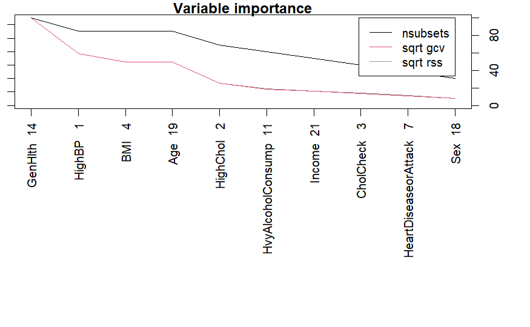

```r
library(earth)
mars <- earth(as.factor(Diabetes_binary) ~ ., data=d2)
ev <- evimp (mars)
par(mar=c(1,1,1,1))
plot(ev)
```

##### Rank Features By Importance

To determine the significance of features in a dataset, a model can be constructed using the available data. Certain techniques, such as decision trees, provide an inherent mechanism to assess variable importance. However, for other algorithms, the importance of variables can be estimated by conducting a ROC curve analysis for each attribute.

```r
library(caret)
control <- trainControl(method="cv", number=4, allowParallel = TRUE)
model <- train(as.factor(Diabetes_binary)~., data=d2, method="lvq", preProcess="scale", trControl=control)
```

##### Feature Selection

To identify the attributes necessary for building an accurate model, automatic feature selection methods can be employed. These methods involve building multiple models using different subsets of a dataset and determining which attributes are essential and which are not.

One widely used automatic feature selection method is Recursive Feature Elimination (RFE), which is available in the caret R package.

During each iteration of RFE, a Random Forest algorithm is utilized to evaluate the model. The algorithm is set up to explore all possible combinations of attribute subsets, allowing for a comprehensive analysis.

```r
control <- rfeControl(functions=rfFuncs, method="cv", number=10)
results <- rfe(d2[,2:22], d2[,1], sizes=c(1:21), rfeControl=control)
print(results)
predictors(results)
plot(results, type=c("g", "o"))
```

[output not shown]

```r
stopCluster(cluster)
registerDoSEQ()
```

#### Feature selection

```r
install.packages("ROCR")
install.packages("ROCR")
library(ROCR)
```

```r
library(caTools)
library(dplyr)
data = data.frame(fread('C:/Users/acer/Desktop/New folder/diabetes_binary_5050split_health_indicators_BRFSS2015.csv', encoding = 'UTF-8'))
sample_data = sample.split(data, SplitRatio = 0.8)
train_data <- subset(data, sample_data == TRUE)
test_data <- subset(data, sample_data == FALSE)
logistic_model <- glm(Diabetes_binary ~., data=train_data)
predict_reg <- predict(logistic_model, test_data, type="response")
predict_reg <- ifelse(predict_reg > 0.5, 1, 0)
missing_classerr <- mean(predict_reg != test_data$Diabetes_binary)
print(paste('Accuracy =', 1 - missing_classerr))
```

```
[1] "Accuracy = 0.748039337731856"
```

### Q3

Yes, feature subset selection plays a crucial role in identifying and eliminating irrelevant and redundant information from the dataset. By doing so, we can reduce the data’s dimensionality, enabling learning algorithms to operate more efficiently and effectively. The methods discussed earlier provide us with the means to select the most significant features for our models.

I have decided to include the following variables in our model: GenHlth, HighBP, BMI, Age, HighChol, HvyAlcoholConsump, and Income. These variables have been deemed important based on their relevance and impact on the model’s performance.

```r
library(plyr)
library(readr)
library(dplyr)
library(caret)
```

```r
d2 = fread('C:/Users/acer/Desktop/New folder/diabetes_binary_5050split_health_indicators_BRFSS2015.csv', encoding = 'UTF-8')
d2 = d2[,c("Diabetes_binary","GenHlth", "HighBP", "BMI", "Age", "HighChol", "HvyAlcoholConsump", "Income")]
d2
```

| Diabetes_binary | GenHlth | HighBP | BMI | Age | HighChol | HvyAlcoholConsump | Income |
| --- | --- | --- | --- | --- | --- | --- | --- |
| 0 | 3 | 1 | 26 | 4 | 0 | 0 | 8 |
| 0 | 3 | 1 | 26 | 12 | 1 | 0 | 8 |
| 0 | 1 | 0 | 26 | 13 | 0 | 0 | 8 |
| 0 | 3 | 1 | 28 | 11 | 1 | 0 | 8 |
| 0 | 2 | 0 | 29 | 8 | 0 | 0 | 8 |
| 0 | 2 | 0 | 18 | 1 | 0 | 0 | 7 |
| 0 | 1 | 0 | 26 | 13 | 1 | 1 | 6 |
| 0 | 4 | 0 | 31 | 6 | 0 | 0 | 3 |
| 0 | 3 | 0 | 32 | 3 | 0 | 0 | 8 |
| 0 | 3 | 0 | 27 | 6 | 0 | 0 | 4 |

[output cut: 990 more lines]

```r
glimpse(d2)
```

```
Rows: 70,692
Columns: 8
$ Diabetes_binary   <dbl> 0, 0, 0, 0, 0, 0, 0, 0, 0, 0, 0, 0, 0, 0, 0, 0, 0, 0, 0, 0, 0…
$ GenHlth           <dbl> 3, 3, 1, 3, 2, 2, 1, 4, 3, 3, 3, 1, 2, 3, 1, 3, 2, 1, 2, 3, 1…
$ HighBP            <dbl> 1, 1, 0, 1, 0, 0, 0, 0, 0, 0, 1, 0, 1, 1, 0, 0, 0, 0, 0, 1, 0…
$ BMI               <dbl> 26, 26, 26, 28, 29, 18, 26, 31, 32, 27, 24, 21, 27, 58, 29, 1…
$ Age               <dbl> 4, 12, 13, 11, 8, 1, 13, 6, 3, 6, 12, 4, 7, 10, 10, 10, 9, 10…
$ HighChol          <dbl> 0, 1, 0, 1, 0, 0, 1, 0, 0, 0, 1, 0, 1, 0, 1, 0, 0, 0, 0, 0, 0…
$ HvyAlcoholConsump <dbl> 0, 0, 0, 0, 0, 0, 1, 0, 0, 0, 0, 0, 0, 0, 0, 0, 0, 0, 0, 0, 0…
$ Income            <dbl> 8, 8, 8, 8, 8, 7, 6, 3, 8, 4, 6, 8, 8, 6, 1, 6, 7, 7, 8, 5, 8…
```

# EDA

Checking if there is a null value in data

```r
# Checking for missing values
sum(is.na(d2))
```

```
[1] 0
```

Now let’s factorize categorical variables

```r
d2[,1:8] <- lapply(d2[,1:8] , as.factor)
d2[,4] <- lapply(d2[,4] , as.numeric)
glimpse(d2)
```

```
Rows: 70,692
Columns: 8
$ Diabetes_binary   <fct> 0, 0, 0, 0, 0, 0, 0, 0, 0, 0, 0, 0, 0, 0, 0, 0, 0, 0, 0, 0, 0…
$ GenHlth           <fct> 3, 3, 1, 3, 2, 2, 1, 4, 3, 3, 3, 1, 2, 3, 1, 3, 2, 1, 2, 3, 1…
$ HighBP            <fct> 1, 1, 0, 1, 0, 0, 0, 0, 0, 0, 1, 0, 1, 1, 0, 0, 0, 0, 0, 1, 0…
$ BMI               <dbl> 15, 15, 15, 17, 18, 7, 15, 20, 21, 16, 13, 10, 16, 47, 18, 7,…
$ Age               <fct> 4, 12, 13, 11, 8, 1, 13, 6, 3, 6, 12, 4, 7, 10, 10, 10, 9, 10…
$ HighChol          <fct> 0, 1, 0, 1, 0, 0, 1, 0, 0, 0, 1, 0, 1, 0, 1, 0, 0, 0, 0, 0, 0…
$ HvyAlcoholConsump <fct> 0, 0, 0, 0, 0, 0, 1, 0, 0, 0, 0, 0, 0, 0, 0, 0, 0, 0, 0, 0, 0…
$ Income            <fct> 8, 8, 8, 8, 8, 7, 6, 3, 8, 4, 6, 8, 8, 6, 1, 6, 7, 7, 8, 5, 8…
```

### Split dataset into Valodation and (training versus test)

To assess the effectiveness of our model, we employ statistical techniques to gauge its accuracy on unseen data. Furthermore, we aim to obtain a more precise estimation of the best model’s accuracy by evaluating it on real unseen data. This involves withholding a portion of the data from the algorithms’ view and using it as a separate source to independently evaluate the actual accuracy of the top-performing model.

```r
#install.packages("caTools")
library(caTools)
d2 = data.frame(d2)
sample_data = sample.split(d2, SplitRatio = 0.8)
data <- subset(d2, sample_data == TRUE)
validation <- subset(d2, sample_data == FALSE)
```

#### Building Models

We will use for different models: Logistic Regression, ROC, Random Forest, NAive Bayes and Decision Tree to train our model, and we will check the accuracy each model gave us.

```r
cv_folds <- createFolds(d2$Diabetes_binary, k = 5, returnTrain = TRUE)
tuneGrid <- expand.grid(.mtry = c(1 : 10))

ctrl <- trainControl(method = "cv",
                     number = 5,
                     search = 'grid',
                     classProbs = TRUE,
                     savePredictions = "final",
                     index = cv_folds,
                     summaryFunction = twoClassSummary) #in most cases a better summary for two class problems

metric = "ROC"
```

#### Logistic Regression

```r
set.seed(7)
fit.lr <- train(make.names(Diabetes_binary)~., data=d2, method="glm", metric=metric, trControl=ctrl)
```

```r
fit.lr
```

```
Generalized Linear Model

70692 samples
    7 predictor
    2 classes: 'X0', 'X1'

No pre-processing
Resampling: Cross-Validated (5 fold)
Summary of sample sizes: 56553, 56553, 56554, 56554, 56554
Resampling results:

  ROC        Sens       Spec
  0.8222325  0.7168562  0.7741189
```

##### Random Forest

```r
set.seed(7)
fit.rf <- train(make.names(Diabetes_binary)~., data=d2, method="rf", metric=metric, trControl=ctrl, ntree = 40,
                       nodesize = c(1, 5))
```

```r
fit.rf
```

```
Random Forest

70692 samples
    7 predictor
    2 classes: 'X0', 'X1'

No pre-processing
Resampling: Cross-Validated (5 fold)
Summary of sample sizes: 56553, 56553, 56554, 56554, 56554
Resampling results across tuning parameters:

  mtry  ROC        Sens       Spec
   2    0.8079592  0.6822266  0.7912356
  14    0.7848131  0.6985515  0.7341712
  27    0.7689758  0.6961183  0.7041535

ROC was used to select the optimal model using the largest value.
The final value used for the model was mtry = 2.
```

##### Decision Tree

```r
set.seed(7)
fit.tree <- train(make.names(Diabetes_binary)~., data=d2, method="rpart", metric=metric, trControl=ctrl)
fit.tree
```

```
CART

70692 samples
    7 predictor
    2 classes: 'X0', 'X1'

No pre-processing
Resampling: Cross-Validated (5 fold)
Summary of sample sizes: 56553, 56553, 56554, 56554, 56554
Resampling results across tuning parameters:

  cp           ROC        Sens       Spec
  0.008940191  0.7332021  0.7068405  0.7020595
  0.011344990  0.7007249  0.6608112  0.7258829
  0.378430374  0.5745367  0.6480407  0.5010327

ROC was used to select the optimal model using the largest value.
The final value used for the model was cp = 0.008940191.
```

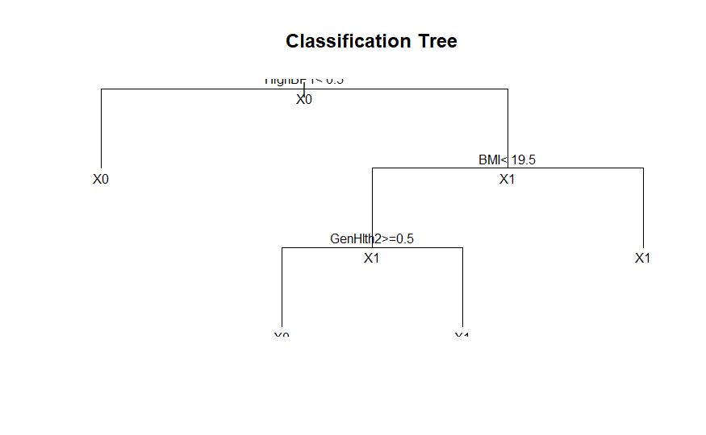

```r
# plot the model
plot(fit.tree$finalModel, uniform=TRUE,
     main="Classification Tree")
text(fit.tree$finalModel, all=TRUE, cex=.8)
```

##### Naive Bayes

```r
set.seed(7)
fit.nb <- train(make.names(Diabetes_binary)~., data=d2, method="nb", metric=metric, trControl=ctrl)
fit.nb
```

[output not shown]

### Model Selection

We employed the ROC metric to assess and compare the models, enabling us to determine the superior one among the rest. Additionally, we have the option to calculate their accuracy or other metrics. As observed, we can compare their CP scores or utilize cross-validation (CV) to identify the optimal model.

```r
results <- resamples(list(DT=fit.tree, LR=fit.lr, RF=fit.rf ))
summary(results)
```

```
Call:
summary.resamples(object = results)

Models: DT, LR, RF
Number of resamples: 5

ROC
        Min.   1st Qu.    Median      Mean   3rd Qu.      Max. NA's
DT 0.7257636 0.7282975 0.7318093 0.7332021 0.7339930 0.7461469    0
LR 0.8172807 0.8190647 0.8212883 0.8222325 0.8255780 0.8279507    0
RF 0.8032652 0.8059273 0.8061756 0.8079592 0.8074524 0.8169753    0

Sens
        Min.   1st Qu.    Median      Mean   3rd Qu.      Max. NA's
DT 0.6729382 0.7058990 0.7107087 0.7068405 0.7222065 0.7224501    0
LR 0.7049088 0.7156599 0.7159428 0.7168562 0.7181047 0.7296647    0
RF 0.6504456 0.6720894 0.6917527 0.6822266 0.6961381 0.7007072    0

Spec
        Min.   1st Qu.    Median      Mean   3rd Qu.      Max. NA's
DT 0.6795869 0.6911869 0.6917527 0.7020595 0.7062235 0.7415476    0
LR 0.7664781 0.7735182 0.7750743 0.7741189 0.7759230 0.7796011    0
RF 0.7691328 0.7773692 0.7964351 0.7912356 0.7995473 0.8136936    0
```

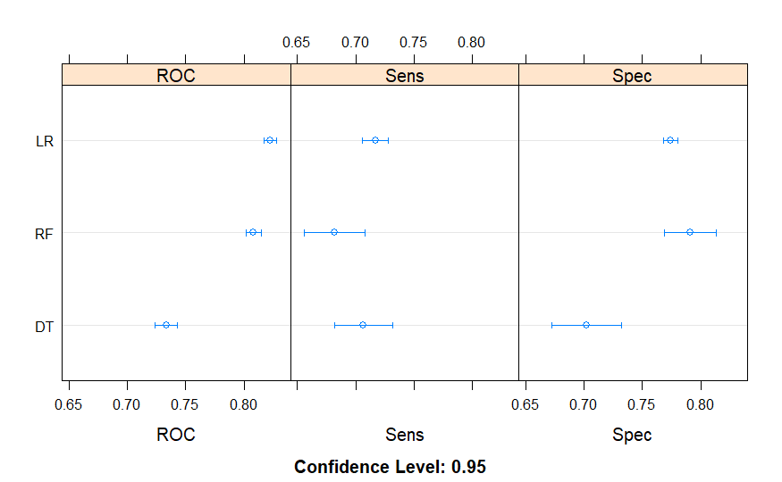

```r
dotplot(results)
```

Based on the observed accuracy and ROC performance, it appears that LR (the generalized linear model) achieves the highest results, followed by RF. However, it is worth noting that better outcomes can be achieved by running RF with a larger number of trees. Due to time constraints in working with caret on large datasets, only a small number of trees were utilized for this analysis.

```r
predictions <- predict(fit.lr, validation)
confusionMatrix(as.factor(predictions), validation$Diabetes_binary)
```

```
Error in confusionMatrix.default(as.factor(predictions), validation$Diabetes_binary) :
  The data must contain some levels that overlap the reference.
```

Both GLM (or LR) and RF demonstrate comparable performance, with GLM slightly outperforming RF. We can proceed with either of them, but if we are compelled to choose just one, LR appears to be the slightly superior option.

### Q4

```r
data = data.frame(d2)
sample_data = sample.split(data, SplitRatio = 0.8)
train_val <- subset(data, sample_data == TRUE)
test <- subset(data, sample_data == FALSE)
sample_data = sample.split(train_val, SplitRatio = 0.8)
train <- subset(train_val, sample_data == TRUE)
val <- subset(train_val, sample_data == FALSE)

logistic_model <- function(alpha){
    logistic_model <- glm(Diabetes_binary~. , data = train, family = "binomial")
    predict_reg <- predict(logistic_model, val , type = "response")
    predictions <- ifelse(predict_reg >alpha, 1, 0)

    confusionMatrix <- confusionMatrix(as.factor(predictions), as.factor(val$Diabetes))
    print(paste("alpha:", alpha))
    print(paste("Accuracy:", confusionMatrix$overall['Accuracy']))
    print(paste("Precision:", confusionMatrix$byClass['Pos Pred Value']))
}


start = 0.2
end = 0.9
step = 0.05
mylist = seq(start, end, by = step)
for (i in mylist){
    print(paste("alpha: ", i))
    logistic_model(i)
}
```

```
[1] "alpha:  0.2"
[1] "alpha: 0.2"
[1] "Accuracy: 0.671193601931492"
[1] "Precision: 0.909123692751532"
[1] "alpha:  0.25"
[1] "alpha: 0.25"
[1] "Accuracy: 0.698657009204768"
[1] "Precision: 0.88869205786832"
[1] "alpha:  0.3"
[1] "alpha: 0.3"
[1] "Accuracy: 0.716915648106232"
[1] "Precision: 0.866242038216561"
[1] "alpha:  0.35"
[1] "alpha: 0.35"
[1] "Accuracy: 0.731326392032594"
```

[output cut: 45 more lines]

sutable alpha is alpha = 0.45

```r
alpha  = 0.45
logistic_model <- glm(Diabetes_binary ~ . , data = train_val, family = "binomial")
predict_reg <- predict(logistic_model, test , type = "response")
predictions <- ifelse(predict_reg >alpha, 1, 0)

confusionMatrix <- confusionMatrix(as.factor(predictions), as.factor(test$Diabetes))
print(paste("alpha:", alpha))
```

```
[1] "alpha: 0.45"
```

```r
print(paste("Accuracy:", confusionMatrix$overall['Accuracy']))
```

```
[1] "Accuracy: 0.7422056243988"
```

```r
print(paste("Precision:", confusionMatrix$byClass['Pos Pred Value']))
```

```
[1] "Precision: 0.780839895013123"
```

### Q5

In this section, we aim to select a model that offers lower computation costs after it is constructed. Generally, non-parametric models like K-nearest neighbors (KNN) are not suitable due to the computational challenges involved in calculating distances for each observation in large spaces. On the other hand, parametric models such as neural networks (NNs) and decision trees (DTs) tend to perform better.

Decision trees have several advantages in terms of speed and efficiency during testing. During inference, test inputs simply need to traverse down the tree until reaching a leaf node, where the prediction is based on the majority label associated with that leaf. This process is comparatively fast. Additionally, decision trees do not require a specific metric because they make splits based on feature thresholds rather than distances. This attribute distinguishes them from KNN, which relies heavily on distance calculations and cannot automatically capture feature interactions.

The speed advantage of decision trees over KNN is primarily attributed to KNN’s expensive real-time execution. Decision trees offer faster predictions, making them more preferable in scenarios where efficiency is crucial.

However, when it comes to prediction accuracy, logistic regression, particularly in terms of F1 score, often performs better. Logistic regression is typically superior in this regard.

Nevertheless, decision trees excel over logistic regression in certain situations. When working with large datasets or when the relationships between different features and the target variable are complex and nonlinear, decision trees prove to be more effective. They can capture intricate patterns and interactions in the data, providing superior performance in such cases.